# ReadLength

Load packages

```r
require(vegan)
require(ggplot2)
require(dplyr)
require(tidyr)
require(viridis)
```

#Water

How does read length affect the percentage of conserved reads?

```r
Water.meta=read.table("Water/Meta.txt")
Water.tracking=read.table("Water/tracking_all.txt")

Water.tracking$Time_since_dist=Water.meta$Time_since_dist[match(Water.tracking$row.names, row.names(Water.meta))]


Water.preserved.reads=ggplot(Water.tracking[which(Water.tracking$Time_since_dist<0),], aes(x=forward.trim, y=100*Non.chimeric.Reads/Original.Reads))+
  geom_point()+
  xlab("Read Length")+
  ylab("% Preserved Reads")+
  theme_minimal()

Water.tracking %>%
  group_by(forward.trim) %>%
  summarise(mean = mean(100*Non.chimeric.Reads/Original.Reads))
```

| forward.trim | mean |
| --- | --- |
| 50 | 90.76709 |
| 60 | 89.80546 |
| 70 | 87.97537 |
| 80 | 82.95932 |
| 90 | 89.08651 |
| 100 | 89.62733 |
| 110 | 90.86255 |
| 120 | 89.88142 |
| 130 | 90.81194 |
| 140 | 90.37824 |

[output cut: 6 more lines]

How does read length affect alpha diversity estimates and rarefaction?

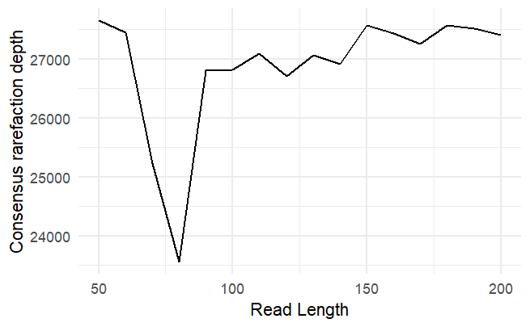

```r
Water.rarefaction=read.table("Water/rarefaction.depth.txt")
Water.rarefaction2=read.table("Water/rarefaction.depth2.txt")

Water.alpha=read.table("Water/alpha.results2.txt", row.names = NULL)

ggplot(Water.rarefaction, aes(x=as.numeric(samplename), y=depth))+
  geom_line()+
  xlab("Read Length")+
  ylab("Consensus rarefaction depth")+
  theme_minimal()
```

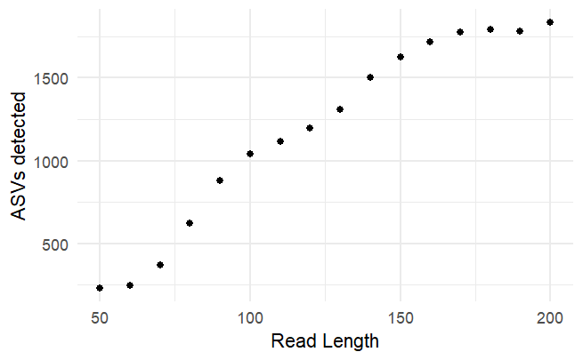

```r
ggplot(Water.rarefaction2, aes(x=as.numeric(samplename), y=ntaxa))+
  geom_point()+
  xlab("Read Length")+
  ylab("ASVs detected")+
  theme_minimal()
```

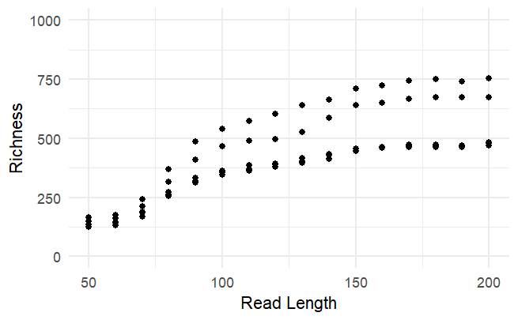

```r
ggplot(Water.alpha, aes(x=as.numeric(samplename), y=richness))+
  geom_point()+
  xlab("Read Length")+
  ylab("Richness")+
  ylim(0, 1000)+
  theme_minimal()
```

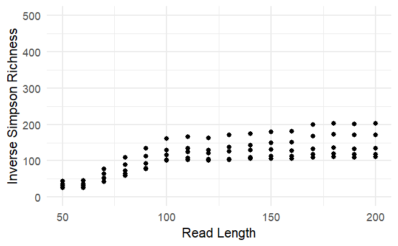

```r
ggplot(Water.alpha, aes(x=as.numeric(samplename), y=simpson))+
  geom_point()+
  xlab("Read Length")+
  ylab("Inverse Simpson Richness")+
  ylim(0, 500)+
  theme_minimal()
```

How does read length affect the number of unclassified ASVS

```r
Water.Unclassfied=read.table("Water/unclassifieds2.txt", header = TRUE)

Water.Unclassified. =Water.Unclassfied %>% pivot_longer(!samplename, names_to = "Taxonomy", values_to = "unclassified.ASVs")
Water.Unclassified.$Taxonomy=as.factor(Water.Unclassified.$Taxonomy)

Water.Unclassified.$Taxonomy =  factor(Water.Unclassified.$Taxonomy, levels=c('Kingdom', 'Phylum', 'Class', 'Order', 'Family', 'Genus'))

Water.Unc=ggplot(Water.Unclassified., aes(x=as.numeric(samplename), y=unclassified.ASVs, color=Taxonomy))+
         geom_line()+
         xlab("Read Length")+
         ylab("Unclassified taxa")+
         scale_color_viridis(discrete = T)+
          theme_minimal()+
   theme(legend.position = "none")
```

How does read length affect the percentage of the community that is unclassified?

```r
Water.Unclassfied.percent=read.table("Water/unclassified.percent.txt", header=TRUE)

Water.Unclassified.percent. =Water.Unclassfied.percent %>% pivot_longer(!samplename, names_to = "Taxonomy", values_to = "Proportion.unclassified")
Water.Unclassified.percent.$Taxonomy=as.factor(Water.Unclassified.percent.$Taxonomy)

Water.Unclassified.percent.$Taxonomy =  factor(Water.Unclassified.percent.$Taxonomy, levels=c('Kingdom', 'Phylum', 'Class', 'Order', 'Family', 'Genus'))

Water.Uncp=ggplot(Water.Unclassified.percent., aes(x=as.numeric(samplename), y=Proportion.unclassified, color=Taxonomy))+
         geom_line()+
         xlab("Read Length")+
         ylab("Unclassified taxa (proportion)")+
         scale_color_viridis(discrete = T)+
         theme_minimal()+
  theme(legend.position = "none")
```

#Pig

How does read length affect the percentage of conserved reads?

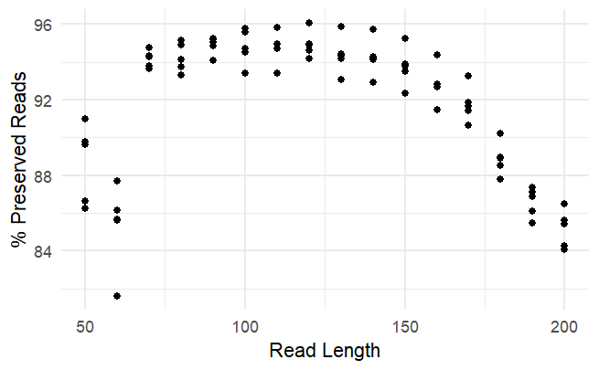

```r
Pig.meta=read.table("Pig/Meta.txt")
Pig.tracking=read.table("Pig/tracking_all.txt")

Pig.tracking$Time_since_dist=Pig.meta$Time_since_dist[match(Pig.tracking$row.names, row.names(Pig.meta))]


Pig.preserved.reads=ggplot(Pig.tracking[which(Pig.tracking$Time_since_dist<0),], aes(x=forward.trim, y=100*Non.chimeric.Reads/Original.Reads))+
  geom_point()+
  xlab("Read Length")+
  ylab("% Preserved Reads")+
  theme_minimal()

Pig.preserved.reads
```

```r
Pig.tracking %>%
  group_by(forward.trim) %>%
  summarise(mean = mean(100*Non.chimeric.Reads/Original.Reads))
```

| forward.trim | mean |
| --- | --- |
| 50 | 93.68905 |
| 60 | 92.17908 |
| 70 | 96.02738 |
| 80 | 95.71901 |
| 90 | 95.91702 |
| 100 | 94.87797 |
| 110 | 94.68315 |
| 120 | 94.15201 |
| 130 | 93.78454 |
| 140 | 92.91689 |

[output cut: 6 more lines]

How does read length affect alpha diversity estimates and rarefaction?

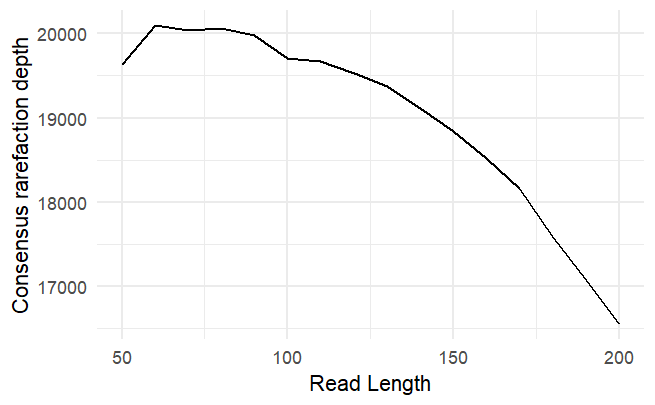

```r
Pig.rarefaction=read.table("Pig/rarefaction.depth.txt")
Pig.rarefaction2=read.table("Pig/rarefaction.depth2.txt")

Pig.alpha=read.table("Pig/alpha.results2.txt", row.names = NULL)

ggplot(Pig.rarefaction, aes(x=as.numeric(samplename), y=depth))+
  geom_line()+
  xlab("Read Length")+
  ylab("Consensus rarefaction depth")+
  theme_minimal()
```

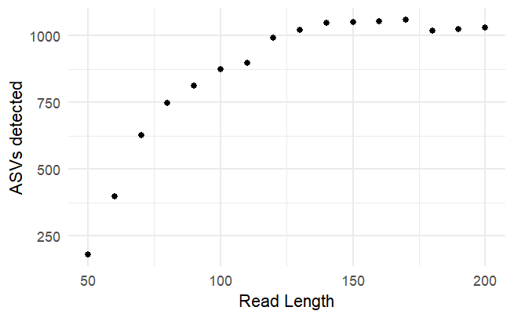

```r
ggplot(Pig.rarefaction2, aes(x=as.numeric(samplename), y=ntaxa))+
  geom_point()+
  xlab("Read Length")+
  ylab("ASVs detected")+
  theme_minimal()
```

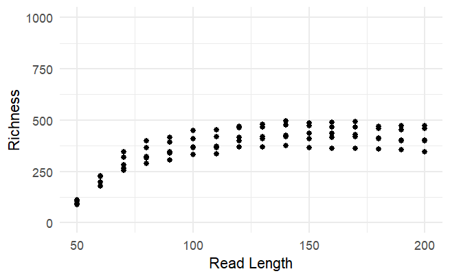

```r
ggplot(Pig.alpha, aes(x=as.numeric(samplename), y=richness))+
  geom_point()+
  xlab("Read Length")+
  ylab("Richness")+
  ylim(0, 1000)+
  theme_minimal()
```

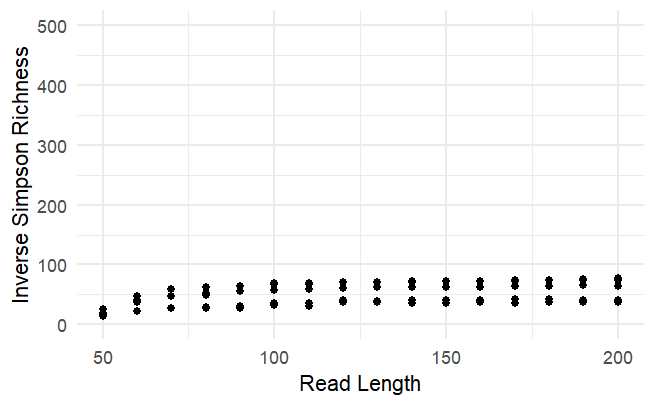

```r
ggplot(Pig.alpha, aes(x=as.numeric(samplename), y=simpson))+
  geom_point()+
  xlab("Read Length")+
  ylab("Inverse Simpson Richness")+
  ylim(0, 500)+
  theme_minimal()
```

How does read length affect the number of unclassified ASVS

```r
Pig.Unclassfied=read.table("Pig/unclassifieds2.txt", header = TRUE)
#Pig.Unclassfied$ntaxa=Pig.rarefaction2$ntaxa

Pig.Unclassified. =Pig.Unclassfied %>% pivot_longer(!c(samplename), names_to = "Taxonomy", values_to = "unclassified.ASVs")

Pig.Unclassified.$Taxonomy=as.factor(Pig.Unclassified.$Taxonomy)

Pig.Unclassified.$Taxonomy =  factor(Pig.Unclassified.$Taxonomy, levels=c('Kingdom', 'Phylum', 'Class', 'Order', 'Family', 'Genus'))

Pig.Unc=ggplot(Pig.Unclassified., aes(x=as.numeric(samplename), y=unclassified.ASVs, color=Taxonomy))+
         geom_line()+
         xlab("Read Length")+
         ylab("Unclassified ASVs")+
         scale_color_viridis(discrete = T)+
         theme_minimal()+
  theme(legend.position = "none")
```

How does read length affect the percentage of the community that is unclassified?

```r
Pig.Unclassfied.percent=read.table("Pig/unclassified.percent.txt", header=TRUE)

Pig.Unclassified.percent. =Pig.Unclassfied.percent %>% pivot_longer(!samplename, names_to = "Taxonomy", values_to = "Proportion.unclassified")
Pig.Unclassified.percent.$Taxonomy=as.factor(Pig.Unclassified.percent.$Taxonomy)

Pig.Unclassified.percent.$Taxonomy =  factor(Pig.Unclassified.percent.$Taxonomy, levels=c('Kingdom', 'Phylum', 'Class', 'Order', 'Family', 'Genus'))

Pig.Uncp=ggplot(Pig.Unclassified.percent., aes(x=as.numeric(samplename), y=Proportion.unclassified, color=Taxonomy))+
         geom_line()+
         xlab("Read Length")+
         ylab("Unclassified ASVs (proportion)")+
         scale_color_viridis(discrete = T)+
         theme_minimal()+
  ylim(0,1)+
  theme(legend.position = "none")
```

#Soil

How does read length affect the percentage of conserved reads?

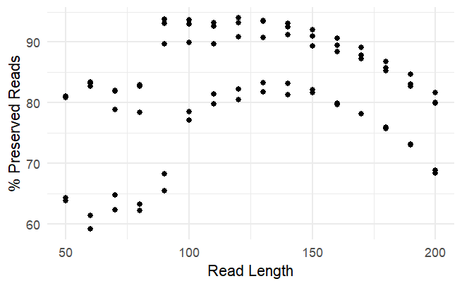

```r
Soil.meta=read.table("Soil/Meta.txt")
Soil.tracking=read.table("Soil/tracking_all.txt")

Soil.tracking$Time_since_dist=Soil.meta$Time_since_dist[match(Soil.tracking$row.names, row.names(Soil.meta))]


Soil.preserved.reads=ggplot(Soil.tracking[which(Soil.tracking$Time_since_dist<0),], aes(x=forward.trim, y=100*Non.chimeric.Reads/Original.Reads))+
  geom_point()+
  xlab("Read Length")+
  ylab("% Preserved Reads")+
  theme_minimal()

Soil.preserved.reads
```

```r
Soil.tracking %>%
  group_by(forward.trim) %>%
  summarise(mean = mean(100*Non.chimeric.Reads/Original.Reads))
```

| forward.trim | mean |
| --- | --- |
| 50 | 79.38347 |
| 60 | 79.85844 |
| 70 | 79.81403 |
| 80 | 79.38063 |
| 90 | 85.05082 |
| 100 | 88.20744 |
| 110 | 88.32717 |
| 120 | 88.36392 |
| 130 | 88.40354 |
| 140 | 86.67264 |

[output cut: 6 more lines]

How does read length affect alpha diversity estimates and rarefaction?

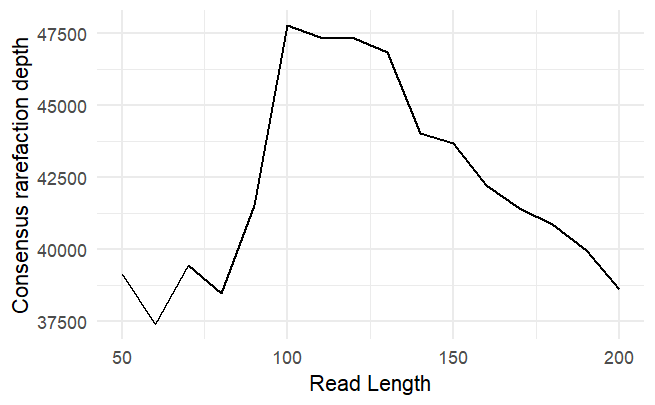

```r
Soil.rarefaction=read.table("Soil/rarefaction.depth.txt")
Soil.rarefaction2=read.table("Soil/rarefaction.depth2.txt")

Soil.alpha=read.table("Soil/alpha.results2.txt", row.names = NULL)

ggplot(Soil.rarefaction, aes(x=as.numeric(samplename), y=depth))+
  geom_line()+
  xlab("Read Length")+
  ylab("Consensus rarefaction depth")+
  theme_minimal()
```

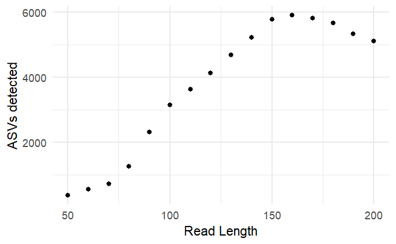

```r
ggplot(Soil.rarefaction2, aes(x=as.numeric(samplename), y=ntaxa))+
  geom_point()+
  xlab("Read Length")+
  ylab("ASVs detected")+
  theme_minimal()
```

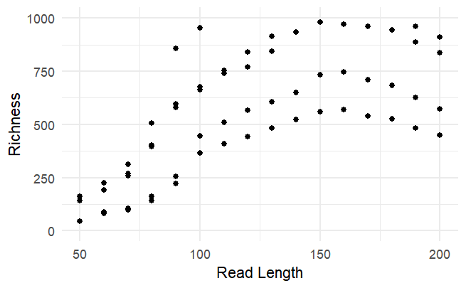

```r
ggplot(Soil.alpha, aes(x=as.numeric(samplename), y=richness))+
  geom_point()+
  xlab("Read Length")+
  ylab("Richness")+
  ylim(0, 1000)+
  theme_minimal()
```

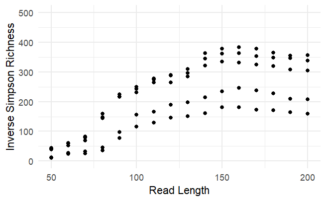

```r
ggplot(Soil.alpha, aes(x=as.numeric(samplename), y=simpson))+
  geom_point()+
  xlab("Read Length")+
  ylab("Inverse Simpson Richness")+
  ylim(0, 500)+
  theme_minimal()
```

How does read length affect the number of unclassified ASVS

```r
Soil.Unclassfied=read.table("Soil/unclassifieds2.txt", header = TRUE)

Soil.Unclassified. =Soil.Unclassfied %>% pivot_longer(!samplename, names_to = "Taxonomy", values_to = "unclassified.ASVs")
Soil.Unclassified.$Taxonomy=as.factor(Soil.Unclassified.$Taxonomy)

Soil.Unclassified.$Taxonomy =  factor(Soil.Unclassified.$Taxonomy, levels=c('Kingdom', 'Phylum', 'Class', 'Order', 'Family', 'Genus'))

Soil.Unc=ggplot(Soil.Unclassified., aes(x=as.numeric(samplename), y=unclassified.ASVs, color=Taxonomy))+
         geom_line()+
         xlab("Read Length")+
         ylab("Unclassified ASVs")+
         scale_color_viridis(discrete = T)+
         theme_minimal()+
  theme(legend.position = "none")
```

How does read length affect the percentage of the community that is unclassified?

```r
Soil.Unclassfied.percent=read.table("Soil/unclassified.percent.txt", header=TRUE)

Soil.Unclassified.percent. =Soil.Unclassfied.percent %>% pivot_longer(!samplename, names_to = "Taxonomy", values_to = "Proportion.unclassified")
Soil.Unclassified.percent.$Taxonomy=as.factor(Soil.Unclassified.percent.$Taxonomy)

Soil.Unclassified.percent.$Taxonomy =  factor(Soil.Unclassified.percent.$Taxonomy, levels=c('Kingdom', 'Phylum', 'Class', 'Order', 'Family', 'Genus'))

Soil.Uncp=ggplot(Soil.Unclassified.percent., aes(x=as.numeric(samplename), y=Proportion.unclassified, color=Taxonomy))+
         geom_line()+
         xlab("Read Length")+
         ylab("Unclassified ASVs (proportion)")+
         scale_color_viridis(discrete = T)+
         theme_minimal()+
  theme(legend.position = "none")
```

#All together now, rarefaction

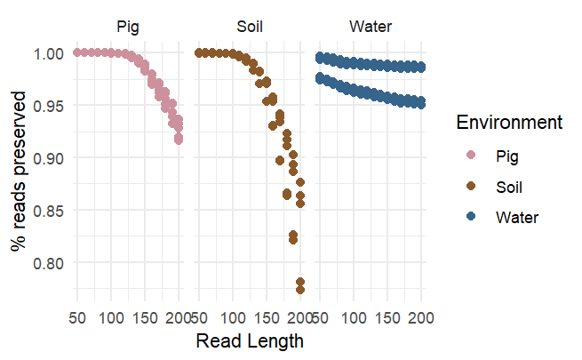

```r
filtered.reads= data.frame(readlength=as.numeric(Water.tracking[which(Water.tracking$Time_since_dist<0),]$forward.trim),
           Water=Water.tracking[which(Water.tracking$Time_since_dist<0),]$Filtered.Reads/Water.tracking[which(Water.tracking$Time_since_dist<0),]$Original.Reads,
           Soil=Soil.tracking[which(Soil.tracking$Time_since_dist<0),]$Filtered.Reads/Soil.tracking[which(Soil.tracking$Time_since_dist<0),]$Original.Reads,
           Pig=Pig.tracking[which(Pig.tracking$Time_since_dist<0),]$Filtered.Reads/Pig.tracking[which(Pig.tracking$Time_since_dist<0),]$Original.Reads)

filtered.reads =filtered.reads %>% pivot_longer(!readlength, names_to = "Environment", values_to = "Preserved")


ggplot(filtered.reads, aes(x=readlength, y=Preserved, color=Environment))+
  geom_point(size=2)+
  xlab("Read Length")+
  ylab("% reads preserved")+
  scale_color_manual(values=c("pink3", "tan4", "steelblue4"))+
  theme_minimal()+
  facet_wrap(~Environment)
```

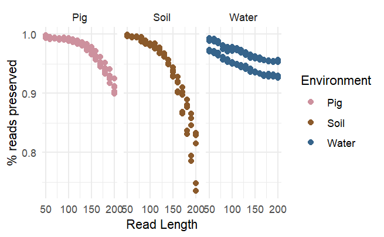

```r
Denoised.reads= data.frame(readlength=as.numeric(Water.tracking[which(Water.tracking$Time_since_dist<0),]$forward.trim),
           Water=Water.tracking[which(Water.tracking$Time_since_dist<0),]$Denoised.Reads/Water.tracking[which(Water.tracking$Time_since_dist<0),]$Original.Reads,
           Soil=Soil.tracking[which(Soil.tracking$Time_since_dist<0),]$Denoised.Reads/Soil.tracking[which(Soil.tracking$Time_since_dist<0),]$Original.Reads,
           Pig=Pig.tracking[which(Pig.tracking$Time_since_dist<0),]$Denoised.Reads/Pig.tracking[which(Pig.tracking$Time_since_dist<0),]$Original.Reads)

Denoised.reads =Denoised.reads %>% pivot_longer(!readlength, names_to = "Environment", values_to = "Preserved")


ggplot(Denoised.reads, aes(x=readlength, y=Preserved, color=Environment))+
  geom_point(size=2)+
  xlab("Read Length")+
  ylab("% reads preserved")+
  scale_color_manual(values=c("pink3", "tan4", "steelblue4"))+
  theme_minimal()+
  facet_wrap(~Environment)
```

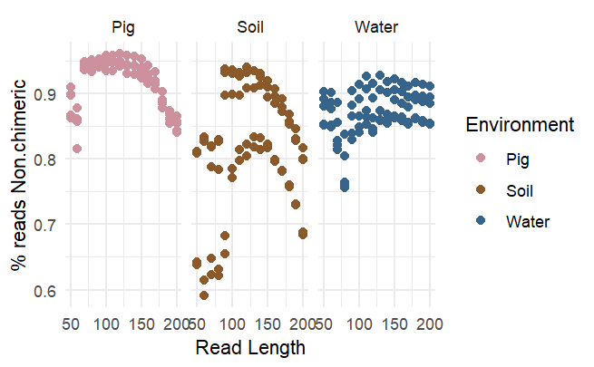

```r
Non.chimeric.reads= data.frame(readlength=as.numeric(Water.tracking[which(Water.tracking$Time_since_dist<0),]$forward.trim),
           Water=Water.tracking[which(Water.tracking$Time_since_dist<0),]$Non.chimeric.Reads/Water.tracking[which(Water.tracking$Time_since_dist<0),]$Original.Reads,
           Soil=Soil.tracking[which(Soil.tracking$Time_since_dist<0),]$Non.chimeric.Reads/Soil.tracking[which(Soil.tracking$Time_since_dist<0),]$Original.Reads,
           Pig=Pig.tracking[which(Pig.tracking$Time_since_dist<0),]$Non.chimeric.Reads/Pig.tracking[which(Pig.tracking$Time_since_dist<0),]$Original.Reads)

Non.chimeric.reads =Non.chimeric.reads %>% pivot_longer(!readlength, names_to = "Environment", values_to = "Non.chimeric")


ggplot(Non.chimeric.reads, aes(x=readlength, y=Non.chimeric, color=Environment))+
  geom_point(size=2)+
  xlab("Read Length")+
  ylab("% reads Non.chimeric")+
  scale_color_manual(values=c("pink3", "tan4", "steelblue4"))+
  theme_minimal()+
  facet_wrap(~Environment)
```

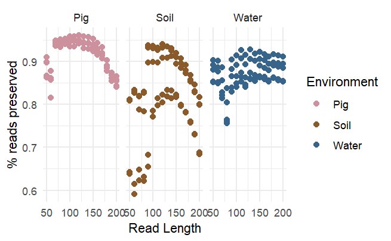

```r
preserved.reads= data.frame(readlength=as.numeric(Water.tracking[which(Water.tracking$Time_since_dist<0),]$forward.trim),
           Water=Water.tracking[which(Water.tracking$Time_since_dist<0),]$Non.chimeric.Reads/Water.tracking[which(Water.tracking$Time_since_dist<0),]$Original.Reads,
           Soil=Soil.tracking[which(Soil.tracking$Time_since_dist<0),]$Non.chimeric.Reads/Soil.tracking[which(Soil.tracking$Time_since_dist<0),]$Original.Reads,
           Pig=Pig.tracking[which(Pig.tracking$Time_since_dist<0),]$Non.chimeric.Reads/Pig.tracking[which(Pig.tracking$Time_since_dist<0),]$Original.Reads)

preserved.reads =preserved.reads %>% pivot_longer(!readlength, names_to = "Environment", values_to = "Preserved")


ggplot(preserved.reads, aes(x=readlength, y=Preserved, color=Environment))+
  geom_point(size=2)+
  xlab("Read Length")+
  ylab("% reads preserved")+
  scale_color_manual(values=c("pink3", "tan4", "steelblue4"))+
  theme_minimal()+
  facet_wrap(~Environment)
```

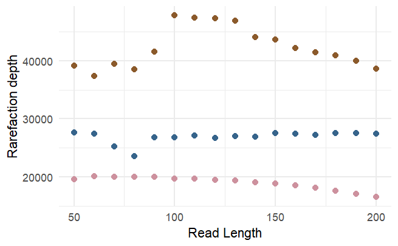

```r
rarefaction.depth=data.frame(readlength=Water.rarefaction$samplename,
                             Water=Water.rarefaction$depth,
                             Soil=Soil.rarefaction$depth,
                             Pig=Pig.rarefaction$depth)

ggplot(rarefaction.depth)+
  geom_point(aes(x=readlength, y=Water), color="steelblue4", size=2)+
  geom_point(aes(x=readlength, y=Soil), color="tan4", size=2)+
  geom_point(aes(x=readlength, y=Pig), color="pink3",size=2)+
  xlab("Read Length")+
  ylab("Rarefaction depth")+
  theme_minimal()
```

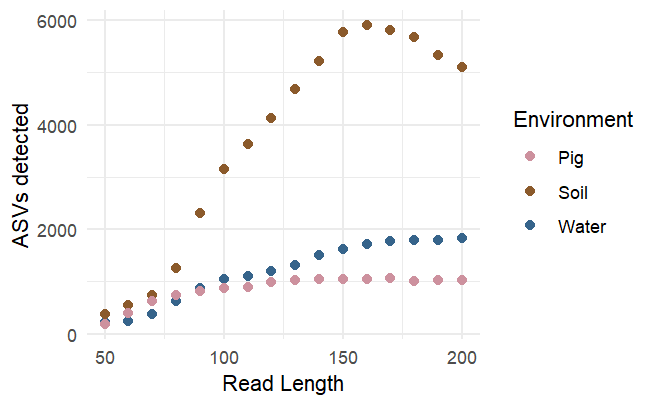

```r
asvs.detected=data.frame(readlength=as.numeric(Water.rarefaction2$samplename),
                             Water=Water.rarefaction2$ntaxa,
                             Soil=Soil.rarefaction2$ntaxa,
                             Pig=Pig.rarefaction2$ntaxa)
asvs.detected =asvs.detected %>% pivot_longer(!readlength, names_to = "Environment", values_to = "ASVs")

ggplot(asvs.detected, aes(x=readlength, y=ASVs, color=Environment))+
  geom_point(size=2)+
  xlab("Read Length")+
  ylab("ASVs detected")+
  scale_color_manual(values=c("pink3", "tan4", "steelblue4"))+
  theme_minimal()
```

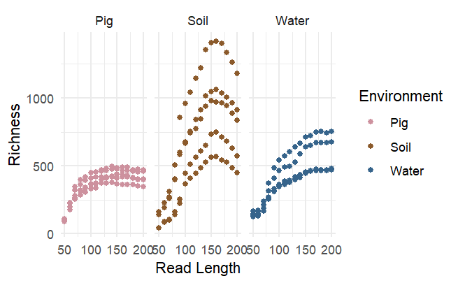

```r
richness=data.frame(readlength=as.numeric(Water.alpha$samplename),
                             Water=Water.alpha$richness,
                             Soil=Soil.alpha$richness,
                             Pig=Pig.alpha$richness)

Richness =richness %>% pivot_longer(!readlength, names_to = "Environment", values_to = "richness")

Richness.=ggplot(Richness, aes(x=readlength, y=richness, color=Environment))+
  geom_point()+
  xlab("Read Length")+
  ylab("Richness")+
  scale_color_manual(values=c("pink3", "tan4", "steelblue4"))+
  facet_wrap(~Environment)+
  theme_minimal()
Richness.
```

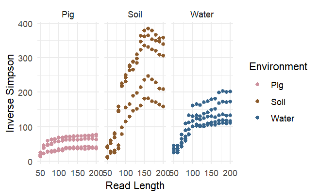

```r
invsimpson=data.frame(readlength=as.numeric(Water.alpha$samplename),
                             Water=Water.alpha$simpson,
                             Soil=Soil.alpha$simpson,
                             Pig=Pig.alpha$simpson)

Invsimpson =invsimpson %>% pivot_longer(!readlength, names_to = "Environment", values_to = "Invsimpson")

Invsimpson.=ggplot(Invsimpson, aes(x=readlength, y=Invsimpson, color=Environment))+
  geom_point()+
  xlab("Read Length")+
  ylab("Inverse Simpson")+
  scale_color_manual(values=c("pink3", "tan4", "steelblue4"))+
  facet_wrap(~Environment)+
  theme_minimal()
Invsimpson.
```

# percent unclassified

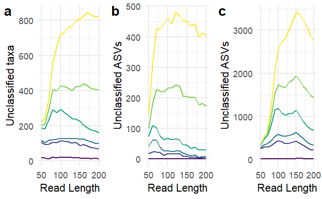

```r
cowplot::plot_grid(Water.Unc, Pig.Unc, Soil.Unc, ncol = 3, labels=c("a","b", "c"))
```

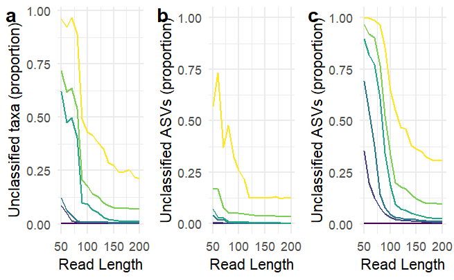

```r
cowplot::plot_grid(Water.Uncp, Pig.Uncp, Soil.Uncp, ncol = 3, labels=c("a","b", "c"))
```

```r
NA
NA
```

#Alpha diversity comparisons

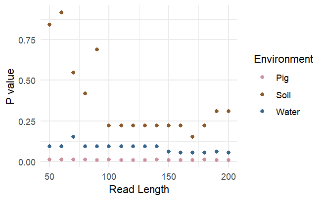

```r
Water.alphap=read.table("Water/alpha.results.diff.txt")
Soil.alphap=read.table("Soil/alpha.results.diff.txt")
Pig.alphap=read.table("Pig/alpha.results.diff.txt")

Richp=data.frame(samplename=Water.alphap$samplename,
                Water=Water.alphap$richness,
                 Pig=Pig.alphap$richness,
                 Soil=Soil.alphap$richness)

Simpsonsp=data.frame(samplename=Water.alphap$samplename,
                     Water=Water.alphap$simpsons,
                 Pig=Pig.alphap$simpsons,
                 Soil=Soil.alphap$simpsons)

Richp =Richp %>% pivot_longer(!samplename, names_to = "Environment", values_to = "Pvalue")

Simpsonsp =Simpsonsp %>% pivot_longer(!samplename, names_to = "Environment", values_to = "Pvalue")

RichnessPs=ggplot(Richp, aes(x=as.numeric(samplename), y=Pvalue, color=Environment))+
  geom_point()+
  xlab("Read Length")+
  ylab("P value")+
  scale_color_manual(values=c("pink3", "tan4", "steelblue4"))+
  theme_minimal()

RichnessPs
```

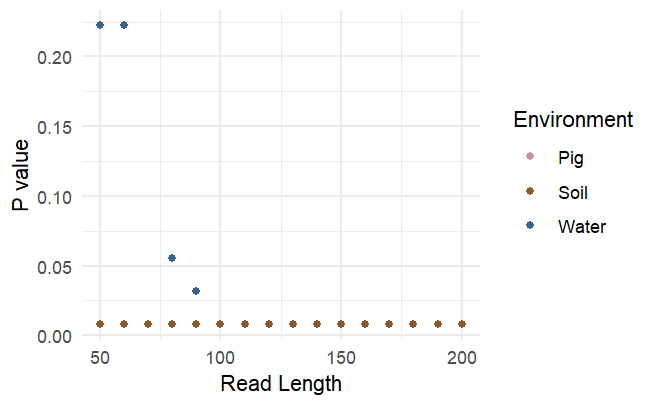

```r
SimpsonsPs=ggplot(Simpsonsp, aes(x=as.numeric(samplename), y=Pvalue, color=Environment))+
  geom_point()+
  xlab("Read Length")+
  ylab("P value")+
  theme_minimal()+
  scale_color_manual(values=c("pink3", "tan4", "steelblue4"))

SimpsonsPs
```

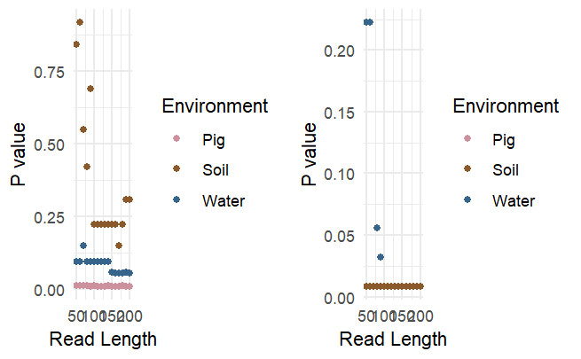

```r
cowplot::plot_grid(RichnessPs, SimpsonsPs)
```

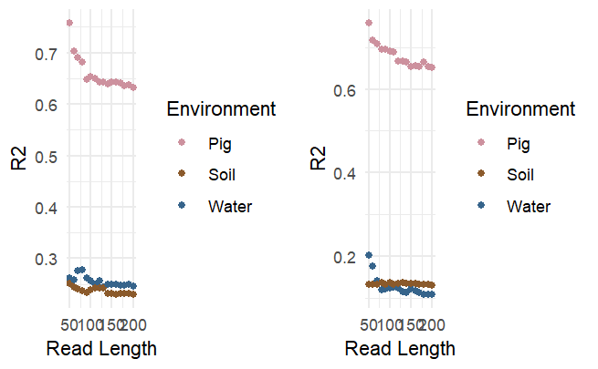

```r
Water.betap=read.table("Water/beta.results.diff.txt")
Soil.betap=read.table("Soil/beta.results.diff.txt")
Pig.betap=read.table("Pig/beta.results.diff.txt")

BrayR=data.frame(samplename=Water.betap$samplename,
                Water=Water.betap$BrayR,
                 Pig=Pig.betap$BrayR,
                 Soil=Soil.betap$BrayR)

SorensenR=data.frame(samplename=Water.betap$samplename,
                Water=Water.betap$SorensenR,
                 Pig=Pig.betap$SorensenR,
                 Soil=Soil.betap$SorensenR)


BrayR. =BrayR %>% pivot_longer(!samplename, names_to = "Environment", values_to = "R2")

SorensenR. =SorensenR %>% pivot_longer(!samplename, names_to = "Environment", values_to = "R2")

BrayR..=ggplot(BrayR., aes(x=as.numeric(samplename), y=R2, color=Environment))+
  geom_point()+
  xlab("Read Length")+
  ylab("R2")+
  theme_minimal()+
  scale_color_manual(values=c("pink3", "tan4", "steelblue4"))

SorensenR..=ggplot(SorensenR., aes(x=as.numeric(samplename), y=R2, color=Environment))+
  geom_point()+
  xlab("Read Length")+
  ylab("R2")+
  theme_minimal()+
  scale_color_manual(values=c("pink3", "tan4", "steelblue4"))


cowplot::plot_grid(BrayR.., SorensenR..)
```

#Mantel correlogram-Bray

```r
Water.bray=readRDS("Water/bray.list2.rds")
Soil.bray=readRDS("Soil/bray.list2.rds")
Pig.bray=readRDS("Pig/bray.list2.rds")

sample.names=paste0(gsub(".merged.rds", "", names(Water.bray)),"0")


Bray.mantel= matrix(ncol = 4, nrow = length(Water.bray))
colnames(Bray.mantel)<-c("samplename", "Water", "Soil", "Pig")


for (i in 1:length(Water.bray)) {
  W=mantel(Water.bray[[i]], Water.bray[[11]], method=
             "pearson")$statistic
    S=mantel(Soil.bray[[i]], Soil.bray[[11]], method=
             "pearson")$statistic
      P=mantel(Pig.bray[[i]], Pig.bray[[11]], method=
             "pearson")$statistic
       Bray.mantel[i,1]=sample.names[i]
       Bray.mantel[i,2]=W
       Bray.mantel[i,3]=S
       Bray.mantel[i,4]=P

}

Bray.mantel=Bray.mantel[-1,]

Bray.mantel. =as.data.frame(Bray.mantel) %>% pivot_longer(!samplename, names_to = "Environment", values_to = "PearsonsR")

B.mantel=ggplot(Bray.mantel., aes(x=as.numeric(samplename), y=as.numeric(PearsonsR), color=Environment))+
  geom_point()+
  xlab("Read Length")+
  ylab("Pearson's R")+
  ylim(0.6,1)+
  theme_minimal()+
  scale_color_manual(values=c("pink3", "tan4", "steelblue4"))
```

#Mantel correlogram-Sorensen

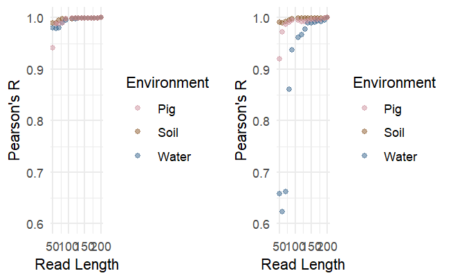

```r
Water.Sorensen=readRDS("Water/Sorensen.list2.rds")
Soil.Sorensen=readRDS("Soil/Sorensen.list2.rds")
Pig.Sorensen=readRDS("Pig/Sorensen.list2.rds")

sample.names=paste0(gsub(".merged.rds", "", names(Water.Sorensen)),"0")


Sorensen.mantel= matrix(ncol = 4, nrow = length(Water.Sorensen))
colnames(Sorensen.mantel)<-c("samplename", "Water", "Soil", "Pig")


for (i in 1:length(Water.Sorensen)) {
  W=mantel(Water.Sorensen[[i]], Water.Sorensen[[11]], method=
             "pearson")$statistic
    S=mantel(Soil.Sorensen[[i]], Soil.Sorensen[[11]], method=
             "pearson")$statistic
      P=mantel(Pig.Sorensen[[i]], Pig.Sorensen[[11]], method=
             "pearson")$statistic
       Sorensen.mantel[i,1]=sample.names[i]
       Sorensen.mantel[i,2]=W
       Sorensen.mantel[i,3]=S
       Sorensen.mantel[i,4]=P

}

Sorensen.mantel=Sorensen.mantel[-1,]

Sorensen.mantel. =as.data.frame(Sorensen.mantel) %>% pivot_longer(!samplename, names_to = "Environment", values_to = "PearsonsR")

S.mantel=ggplot(Sorensen.mantel., aes(x=as.numeric(samplename), y=as.numeric(PearsonsR), color=Environment))+
  geom_point(alpha=0.5)+
  xlab("Read Length")+
  ylab("Pearson's R")+
  ylim(0.6,1)+
  theme_minimal()+
  scale_color_manual(values=c("pink3", "tan4", "steelblue4"))

cowplot::plot_grid(B.mantel, S.mantel)
```

Without chimera checking

#NOCHIMERAMantel correlogram-Bray

```r
Water.bray=readRDS("Water/Nochim/bray.list2.rds")
Soil.bray=readRDS("Soil/Nochim/bray.list2.rds")
Pig.bray=readRDS("Pig/Nochim/bray.list2.rds")

sample.names=paste0(gsub(".merged.rds", "", names(Water.bray)),"0")


Bray.mantel= matrix(ncol = 4, nrow = length(Water.bray))
colnames(Bray.mantel)<-c("samplename", "Water", "Soil", "Pig")


for (i in 1:length(Water.bray)) {
  W=mantel(Water.bray[[i]], Water.bray[[11]], method=
             "pearson")$statistic
    S=mantel(Soil.bray[[i]], Soil.bray[[11]], method=
             "pearson")$statistic
      P=mantel(Pig.bray[[i]], Pig.bray[[11]], method=
             "pearson")$statistic
       Bray.mantel[i,1]=sample.names[i]
       Bray.mantel[i,2]=W
       Bray.mantel[i,3]=S
       Bray.mantel[i,4]=P

}

Bray.mantel=Bray.mantel[-1,]

Bray.mantel. =as.data.frame(Bray.mantel) %>% pivot_longer(!samplename, names_to = "Environment", values_to = "PearsonsR")

B.mantel=ggplot(Bray.mantel., aes(x=as.numeric(samplename), y=as.numeric(PearsonsR), color=Environment))+
  geom_point(alpha=0.5)+
  xlab("Read Length")+
  ylab("Pearson's R")+
  ylim(0.6,1)+
  theme_minimal()+
  scale_color_manual(values=c("pink3", "tan4", "steelblue4"))
```

#NOCHIMERAMantel correlogram-Sorensen

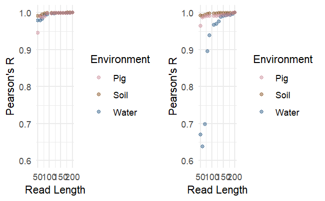

```r
Water.Sorensen=readRDS("Water/Nochim/Sorensen.list2.rds")
Soil.Sorensen=readRDS("Soil/Nochim/Sorensen.list2.rds")
Pig.Sorensen=readRDS("Pig/Nochim/Sorensen.list2.rds")

sample.names=paste0(gsub(".merged.rds", "", names(Water.Sorensen)),"0")


Sorensen.mantel= matrix(ncol = 4, nrow = length(Water.Sorensen))
colnames(Sorensen.mantel)<-c("samplename", "Water", "Soil", "Pig")


for (i in 1:length(Water.Sorensen)) {
  W=mantel(Water.Sorensen[[i]], Water.Sorensen[[11]], method=
             "pearson")$statistic
    S=mantel(Soil.Sorensen[[i]], Soil.Sorensen[[11]], method=
             "pearson")$statistic
      P=mantel(Pig.Sorensen[[i]], Pig.Sorensen[[11]], method=
             "pearson")$statistic
       Sorensen.mantel[i,1]=sample.names[i]
       Sorensen.mantel[i,2]=W
       Sorensen.mantel[i,3]=S
       Sorensen.mantel[i,4]=P

}

Sorensen.mantel=Sorensen.mantel[-1,]

Sorensen.mantel. =as.data.frame(Sorensen.mantel) %>% pivot_longer(!samplename, names_to = "Environment", values_to = "PearsonsR")

S.mantel=ggplot(Sorensen.mantel., aes(x=as.numeric(samplename), y=as.numeric(PearsonsR), color=Environment))+
  geom_point(alpha=0.5)+
  xlab("Read Length")+
  ylab("Pearson's R")+
  ylim(0.6,1)+
  theme_minimal()+
  scale_color_manual(values=c("pink3", "tan4", "steelblue4"))

cowplot::plot_grid(B.mantel, S.mantel)
```